# Introduction to `SimKriging` Package

In this document, we illustrate the R package `SimKriging` (https://github.com/tianyi-pan/SimKriging) for simulation study of relative prediction efficiency of kriging to co-kriging, which is a replication the simulation study in Zhang and Cai (2015). The R script and results can be found in the [repos](https://github.com/tianyi-pan/STAT900-Final-Code).

```r
## Some dependencies
# install.packages(c('Rcpp', 'RcppEigen', 'RcppArmadillo'))
# install.packages('devtools')

## Install Package
devtools::install_github('tianyi-pan/SimKriging')
```

```r
## load package
library(SimKriging)
```

# Description of `SimKriging` Package

We seek to address the open question proposed in the assigned paper (Genton and Kleiber 2015), “for the proposes of co-kriging, in what situations are the use of nontrivial cross-covariances beneficial”, under the specific case:

Following Genton and Kleiber (2015), we consider a bivariate Gaussian process with mean 0 and the exponential cross-covariance functions in a one-dimension spatial coordinate.

Let $\boldsymbol{Y}(\boldsymbol{s}) = [Y_1(\boldsymbol{s}),Y_2(\boldsymbol{s})]^\mathrm{T}$ be a stationary bivariate Gaussian process. The spatial process $Y_1(\boldsymbol{s})$ that we aim to predict is called the primary process,and then $Y_2(\boldsymbol{s})$ is called the auxiliary process.

The exponential cross-covariance function is specified as follows,
$$C_{ij}(\boldsymbol{s}_1, \boldsymbol{s}_2) = \sigma_{ij}^2 \exp
(-\alpha ||\boldsymbol{h}||), \quad i, j = 1, 2,$$
where $\boldsymbol{h} = \boldsymbol{s}_1-\boldsymbol{s}_2$ and $||\cdot||$ denotes the Euclidean norm. $C_{ij}(\cdot,\cdot)$ is the cross-covariance function define in Genton and Kleiber (2015), and $\alpha > 0$ is the scale parameter Gneiting et al. (2010). The marginal covariances $\sigma_{12}^2$ and $\sigma_{21}^2$ can be reparametrized as $r \sigma_{11} \sigma_{22}$, where $r$ is the correlation coefficient of $Y_1(s)$ and $Y_2(s)$ Genton and Kleiber (2015).

The data are sampled by a certain scheme as in Zhang and Cai (2015).

Our research question is:

Under the specific case, how do the scale parameter $\alpha$, correlation coefficient $r$ and sample size $n$ affect the relative prediction efficiency of kriging to co-kriging, where the prediction efficiency is measured by mean squared prediction error?

The package `SimKriging` was designed to investigate the results question through simulation studies.

The performance measure is selected as the Relative Prediction Efficiency (RPE) following Zhang and Cai (2015),

$$\text{RPE} = \frac{\mathrm{E}(Y_1(0) -
\widehat{Y}_{1,\text{co-kriging}}(0))^2}{\mathrm{E}(Y_1(0) -
\widehat{Y}_{1,\text{kriging}}(0))^2},$$
where $\mathrm{E}(Y_1(0) - \widehat{Y}_{1,\text{co-kriging}}(0))^2$ and $\mathrm{E}(Y_1(0) - \widehat{Y}_{1,\text{kriging}}(0))^2$ are MSPE’s of co-kriging and kriging predictors for $Y_1(0)$.

# An example for `SimKriging` Package

We will describe how to use the package through an example with the following choice of levels as in the final report and Zhang and Cai (2015):

- Correlation coefficient $r$: 0.2, 0.5
- Scale parameter $\alpha$: 2, 4, 8
- Sample size $n$: 10, 20, 30, 40, 50, 60, 100

## Main function

The main function of the package is `do_sim()`, to run a simulation under one setting, which can be specified through the following arguments,

- `alpha`: scale parameter
- `sigma11`: marginal variance for the primary process
- `sigma22`: marginal variance for the auxiliary process
- `rho`: correlation coefficient
- `n`: sample size
- `R`: number of simulation, default to `5e6`
- `seed`: random seed

In this example, we set the following vector for the level of parameters,

```r
## scale parameter
alpha <- 4
## marginal variance
sigma11 <- sigma22 <- 1
## correlation coefficient
rho <- 0.2
## sample size
n <- 10
```

Then, we pass the arguments into the function `do_sim()`. The default number of simulation is `5e6`, and we set random seed as `6789`

```r
do_sim(alpha = alpha, sigma11 = sigma11, sigma22 = sigma22,
       rho = rho, n = n, seed = 6789)
```

```
#> [1] 0.9828559
```

```r
# takes around 20 seconds...
```

The `do_sim` function will generate a large matrix using Cpp code and implement most steps by matrix multiplications. If we increase the sample size `n`, the code cannot run in a laptop (unless you have a high-end computer with e.g. 32GB…). Therefore, we provide another option using `sapply` function to release memory pressure:

- `limited.memory`: FALSE (default): use the matrix form (need a large memory) or TRUE: the sapply loop (for limited memory)

By setting `limited.memory = TRUE`, we could run for example `n = 20` in laptops. It will show a progress bar if runing the code in terminal or Rstudio.

```r
do_sim(alpha = alpha, sigma11 = sigma11, sigma22 = sigma22,
       rho = rho, n = 20, seed = 6789,
       limited.memory = TRUE)
# takes around 2 min ...
```

We would recommand that you run setting with larger `n` in a server, for example fastlinux in MFCF, along with specifying `limited.memory = FALSE`.

## Reproduce main results in the final report

For the whole simulation in the final report, we provide a function `simulation()`, which accept a list of parameters, and all the combinations will be passed to `do_sim()`.

For example, in our simulation study, we choose the following parameters for the scale parameter `alpha`, marginal variance `sigma11, sigma22`, correlation coefficient `rho` and sample size `n`:

```r
alpha.list = c(2,4,8) # scale parameter
sigma11.list = c(1) # marginal variance
sigma22.list = c(1) # marginal variance
rho.list = c(0.2, 0.5) # correlation coefficient
n.list = c(10,20,30,40,50,60,100) # sample size
R = 5e6 # number of simulation
```

We can run the following code in a server (e.g. fastlinux in MFCF),

```r
## takes 30 mins in MFCF cpu150 using a single core.
main.results <- simulation(alpha.list, sigma11.list, sigma22.list, rho.list,
                           n.list, R, seed = 6789)
```

It will take 30 minutes in MFCF cpu150.

We would recommend that you run the `do_sim()` function introduced in the previous section to test the package, or the following minimal working example,

```r
## takes 1 second ...
MWE <- simulation(alpha.list = c(2),
                  sigma11.list = c(2),
                  sigma22.list = c(2),
                  rho.list = c(0.2, 0.5),
                  n.list = c(10, 20),
                  R = 100, seed = 6789)
```

```
#>   alpha sigma11 sigma22     rho       n       R
#>     2.0     2.0     2.0     0.2    10.0   100.0
#>   alpha sigma11 sigma22     rho       n       R
#>     2.0     2.0     2.0     0.5    10.0   100.0
#>   alpha sigma11 sigma22     rho       n       R
#>     2.0     2.0     2.0     0.2    20.0   100.0
#>   alpha sigma11 sigma22     rho       n       R
#>     2.0     2.0     2.0     0.5    20.0   100.0
```

In this vignette, we will not rerun the simulation but load the results instead. The results can be found in the [repos](https://github.com/tianyi-pan/STAT900-Final-Code/tree/main/results).

```r
load("results/main_results.RData")
```

The return of the `simulation` function is an S3 class, which is named as `simkriging_main`. We can check it by the base function `class()` in R,

```r
class(main.results)
```

```
#> [1] "simkriging_main"
```

## Monte Carlo Standrad Error (MCSE) in the final report

There is no closed form for the Monte Carlo standard error (MCSE) of relative prediction efficiency in Morris et al. (2019). Therefore, we will repeat the simulation study 300 times under different random seeds to estimate the MCSE.

In the `simulation` function, we could estimate MCSE by setting `estimate.MCSE = TRUE`, and the number of repetition is specified by `rep.MCSE`, for example `rep.MCSE = 300` for 300 times of repetition. We could also set `ncores` greater than 1 to run the code parallelly.

```r
## Repeat the simulation 300 times.
## Do NOT Run it! load(file.path(filepath,"MCSE_results.RData")) instead.
## It will take at least 2 DAYS in MFCF cpu150 using a multi-core (4 corse, limited by the Memory).
MCSE.results <- simulation(alpha.list, sigma11.list, sigma22.list, rho.list,
                           n.list, R, seed = 6789,
                           estimate.MCSE = TRUE, rep.MCSE = 300,
                           ncores = 4)
```

In this vignette, we will not run the code but load the results instead. The results can be found in the [repos](https://github.com/tianyi-pan/STAT900-Final-Code/tree/main/results).

```r
load("results/MCSE_results.RData")
```

The return of the `simulation` function by setting `estimate.MCSE = TRUE` is a S3 class named as `simkriging_MCSE`.

```r
class(MCSE.results)
```

```
#> [1] "simkriging_MCSE"
```

## Summarize Results in Tables

The return dataframe containing the following columns: + `rho`: correlation coefficient + `alpha`: scale parameter + `n`: sample size + `RE`: relative prediction efficiency

For example, we choose correlation coefficient `rho` as 0.2, scale parameter `alpha` as 4,

```r
summary(main.results, rho.select = 0.2, alpha.select = 4)
```

| rho | alpha | n | RE |
| --- | --- | --- | --- |
| 0.2 | 4 | 10 | 0.9829 |
| 0.2 | 4 | 20 | 0.9809 |
| 0.2 | 4 | 30 | 0.9805 |
| 0.2 | 4 | 40 | 0.9803 |
| 0.2 | 4 | 50 | 0.9803 |
| 0.2 | 4 | 60 | 0.9802 |
| 0.2 | 4 | 100 | 0.9801 |

The same function works for MCSE,

```r
summary(MCSE.results, rho.select = 0.2, alpha.select = 4)
```

| rho | alpha | n | mcse |
| --- | --- | --- | --- |
| 0.2 | 4 | 10 | 0.00011 |
| 0.2 | 4 | 20 | 0.00012 |
| 0.2 | 4 | 30 | 0.00012 |
| 0.2 | 4 | 40 | 0.00012 |
| 0.2 | 4 | 50 | 0.00013 |
| 0.2 | 4 | 60 | 0.00012 |
| 0.2 | 4 | 100 | 0.00011 |

## Summarize Results in Figures

Beside the tables from `summary` function, we also provide a `plot()` function to visualize the main simulation results in line plots. Note that the plot function only works for `simkriging_main` object.

The S3 method for the simulation results is `plot.simkriging_main`. We could call the `plot()` function for the returned `simkriging_main` object from `simulation()` function.

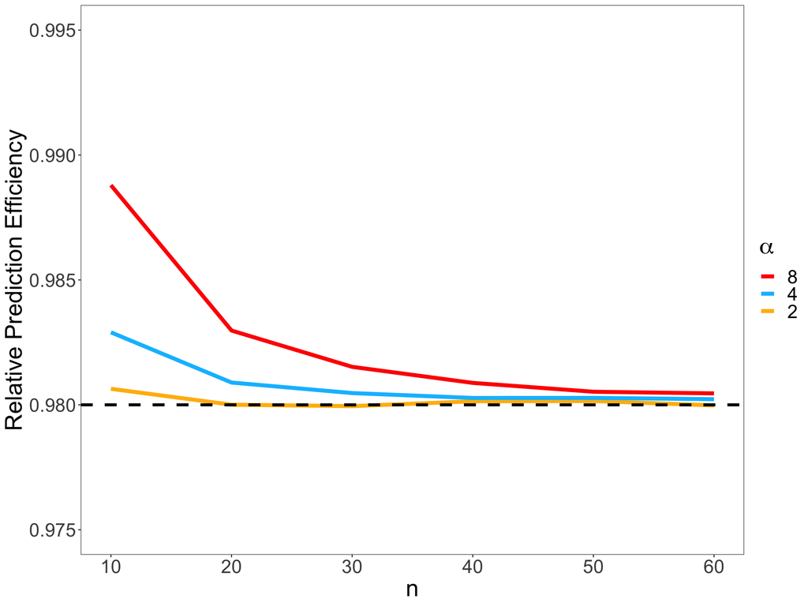

```r
plot(main.results, rho.select = 0.2)
```

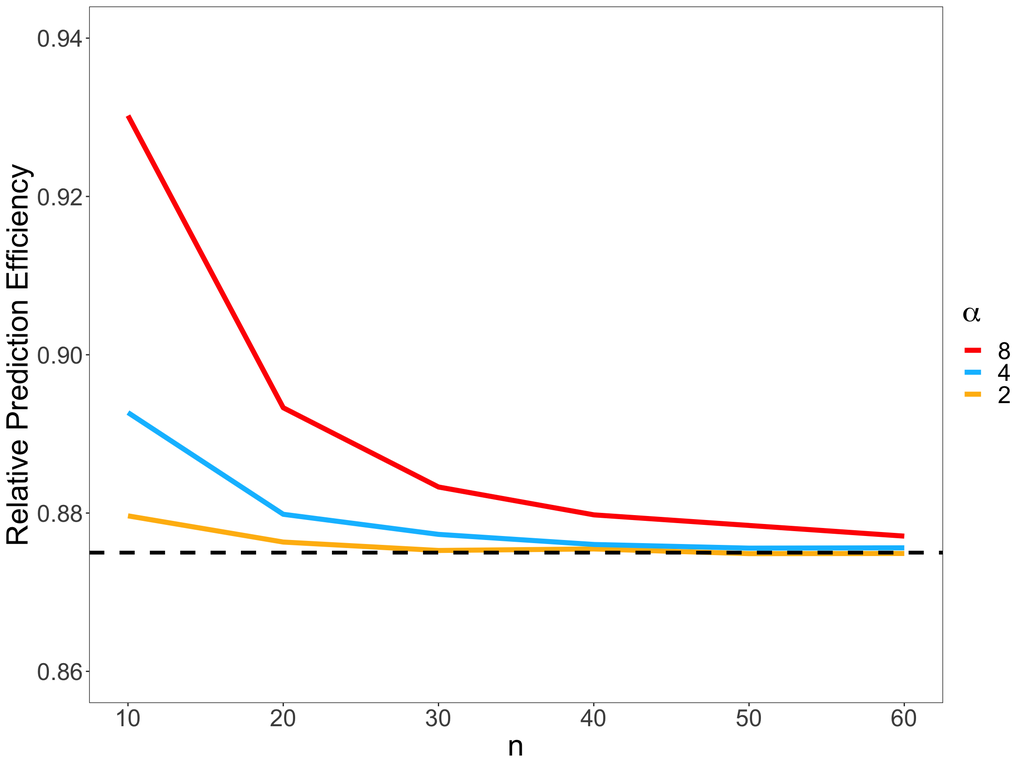

```r
plot(main.results, rho.select = 0.5)
```

The figures are same as Fig2 in Zhang and Cai (2015), which indicates that their simulation results are reproducible.

The functions described above are the core functions in `SimKriging` package. For more information, you could use `?` for the name of function to check the manual page.

## Examples of Tests

We use the unit test package `testthat` in R for testing, and our package passes the tests.

The arguments passing to the main function `do_sim()` should satisfy the following constraints:

- `alpha`: scale parameter > 0
- `sigma11`: marginal variance for the primary process > 0
- `sigma22`: marginal variance for the auxiliary process > 0
- `rho`: correlation coefficient in [-1,1]
- `n`: sample size > 0, integer
- `R`: number of simulation > 0, integer

All the constraints will be checked in `do_sim()` function. Here are some examples,

```r
library(testthat)
test_that("the scale parameter should be positive",{
  expect_error(do_sim(alpha = -2, sigma11 = 1, sigma22 = 1, rho = 0.2, n = 10, R = 100))
})
```

```
#> Test passed 😀
```

```r
try(do_sim(alpha = -2, sigma11 = 1, sigma22 = 1, rho = 0.2, n = 10, R = 100))
```

```
#> Error in do_sim(alpha = -2, sigma11 = 1, sigma22 = 1, rho = 0.2, n = 10,  :
#>   is.numeric(alpha) & alpha > 0 is not TRUE
```

```r
test_that("the number of simulation should be an integer",{
  expect_error(do_sim(alpha = 2, sigma11 = 1, sigma22 = 1, rho = 0.2, n = 10, R = 5.5))
})
```

```
#> Test passed 😀
```

```r
try(do_sim(alpha = 2, sigma11 = 1, sigma22 = 1, rho = 0.2, n = 10, R = 5.5))
```

```
#> Error in do_sim(alpha = 2, sigma11 = 1, sigma22 = 1, rho = 0.2, n = 10,  :
#>   R%%1 == 0 & R > 0 is not TRUE
```

We also check the output of `simulation()` function. Her are some examples,

```r
test_that("simulation output contains appropriate results",{
  results <- simulation(2, 1, 1, c(0.2, 0.5), 10, R = 100)
  expect_true(class(results) == "simkriging_main")
  expect_true(!is.null(results$RE)) ## calculate RE correctly
  expect_true(unique(unlist(lapply(results, length))) == 2) ## length of results
})
```

```
#>   alpha sigma11 sigma22     rho       n       R
#>     2.0     1.0     1.0     0.2    10.0   100.0
#>   alpha sigma11 sigma22     rho       n       R
#>     2.0     1.0     1.0     0.5    10.0   100.0
#> Test passed 🎊
```

# References

Genton, M. G., and Kleiber, W. (2015), “Cross-covariance functions for multivariate geostatistics,” *Statistical Science*, 30, 147–163.

Gneiting, T., Kleiber, W., and Schlather, M. (2010), “Matérn cross-covariance functions for multivariate random fields,” *Journal of the American Statistical Association*, Taylor & Francis, 105, 1167–1177.

Morris, T. P., White, I. R., and Crowther, M. J. (2019), “Using simulation studies to evaluate statistical methods,” *Statistics in medicine*, Wiley Online Library, 38, 2074–2102.

Zhang, H., and Cai, W. (2015), “When doesn’t cokriging outperform kriging?” *Statistical Science*, JSTOR, 176–180.